# final_presentation_internship slides

[figure not shown]

### **About LIQOMICS**

- **Academic Spin-off from Cologne:**  
  Focused on cutting-edge tumor diagnostics through liquid biopsy technology.

### **Key Service: LymphoVista**

- **What It Does:**  
  Detects and monitors **lymphomas** and **hematological cancers**.
- **How It Works:**
  - **Blood Sample Analysis:** Detects **cell-free DNA** and **circulating tumor DNA**.
  - **Disease Monitoring:** Tracks **Minimal Residual Disease (MRD)** to assess treatment response.

### **Sensitive MRD Testing for Cancer Monitoring**

[figure not shown]

## **Cell-Free DNA (cfDNA)**

### **What Is cfDNA?**

- **Degraded Small DNA Fragments:**
  - Size: **50 - 200 bp**, cleaved by **nucleases**.

### **Source of cfDNA:**

- **Released by Dead Cells:**
  - Occurs via **apoptosis**, **necrosis**, or **active secretion** from living cells.

### **Key Molecular Features:**

- **Tissue-Specific Signatures:**
  - **Fragment Size:** Reflects tissue-specific fragmentation patterns.
  - **Methylation Status:** Epigenetic modifications characteristic of cell types.
  - **End Motifs:** Specific DNA ends reflecting nuclease activity.

### **Chromatin Organization and Nuclease Activity Define cfDNA Signatures**

[figure not shown]

## **Projects Overview**

### **1. Hodgkin Lymphoma Project**

- **Data Source:**
  - Cell-free DNA sequencing from **Hodgkin Lymphoma Patients**.
  - Samples collected **before** and **after two cycles of chemotherapy**.
  - Additional **relapse information** included.
- **Goal:**
  - Build a **Machine Learning Model** to **predict relapse** after treatment.
- **Result:**
  - **Challenge:** Insufficient sample size for a reliable predictive model.

## **Projects Overview**

### **2. Solid Tumors (Finale_DB Project)**

- **Data Source:**
  - Cell-free DNA sequencing from **4 Publications:**
    - **Jiang_2015, Cristiano_2019, Snyder_2016, Sun_2019**.
  - **>800 Samples:** Includes both **healthy** and **cancer** samples.
- **Goal:**
  - Develop a **Machine Learning Model** to **distinguish cancer from non-cancer** for solid tumors.

**Note:** Detailed results from this project will be presented on the following slides.

Summary of Data Sources and Samples

| Source | Diseases Covered | Total Samples |
| --- | --- | --- |
| Cristiano_2019 | Bile_duct_cancer Breast_cancer Colorectal_cancer Duodenal_cancer Gastric_cancer Healthy Lung_cancer Ovarian_cancer Pancreatic_cancer | 536 |
| Jiang_2015 | Cirrhosis Healthy Hepatitis_B Liver_cancer | 225 |

| Source | Diseases Covered | Total Samples |
| --- | --- | --- |
| Snyder_2016 | Bladder_cancer Breast_cancer Colorectal_cancer Esophageal_cancer Head_and_neck_cancer Healthy Inflammatory_bowel_disease Kidney_cancer Liver_cancer Lung_cancer Ovarian_cancer Pancreatic_cancer Prostat… | 58 |
| Sun_2019 | Colorectal_cancer Liver_transplant | 29 |

## **Pipeline**

1. Downsampling
2. Feature Normalization
3. Feature Selection
4. Machine learning (TPOT)

[figure not shown]

## **Downsampling Process**

### **Key Steps:**

1. **Handling Coverage Variability:**
   - Coverage between samples **varies significantly**, affecting comparability.
2. **Equalization:**
   - **Downsample all samples** to the same number of **DNA fragments** to ensure consistency in analysis.

```
Number of total samples after downsampling: 848
```

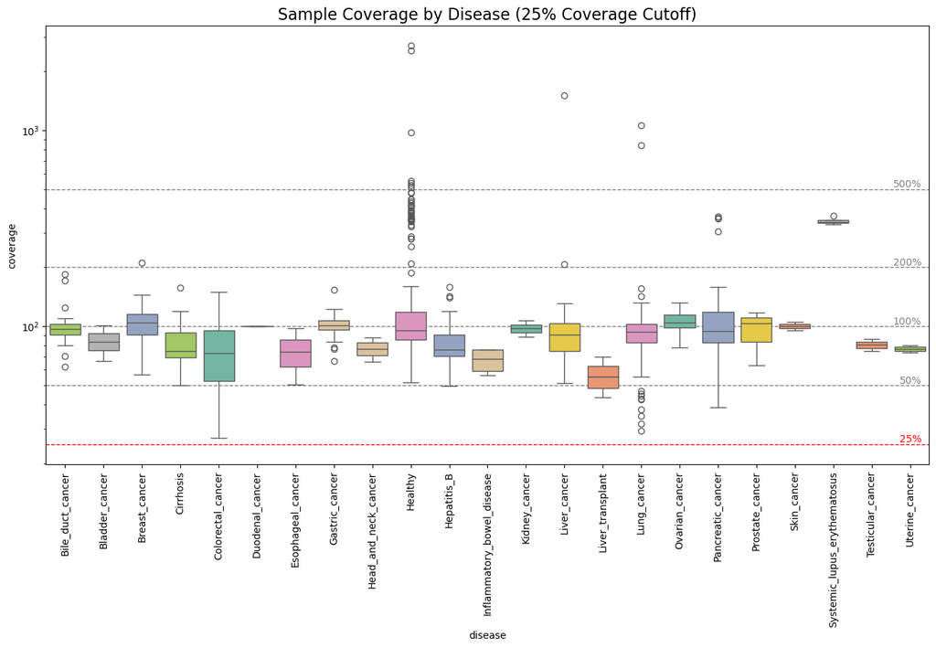

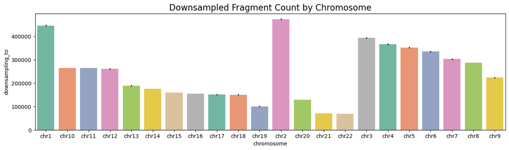

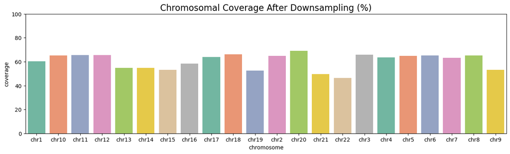

## **Feature Normalization Process**

### **Key Steps:**

1. **Window Sampling:**
   - Process **5 million windows** on each chromosome for accurate feature representation.
2. **Normalization:**
   - Apply **feature normalization** to prepare data for **machine learning** models.
3. **Data Readiness:**
   - Ensure features are **scaled** and **standardized** for better model performance.

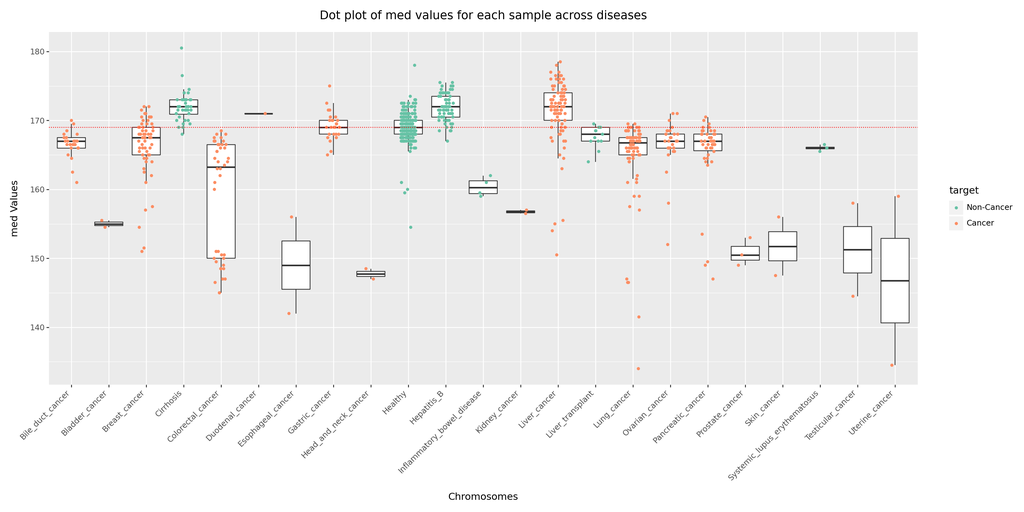

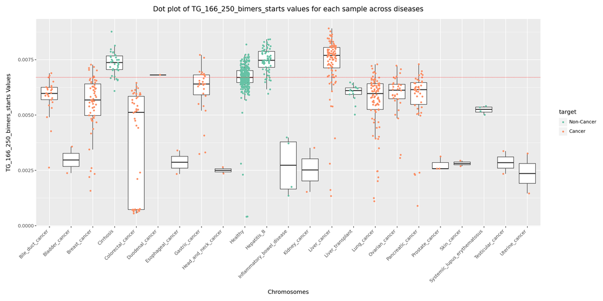

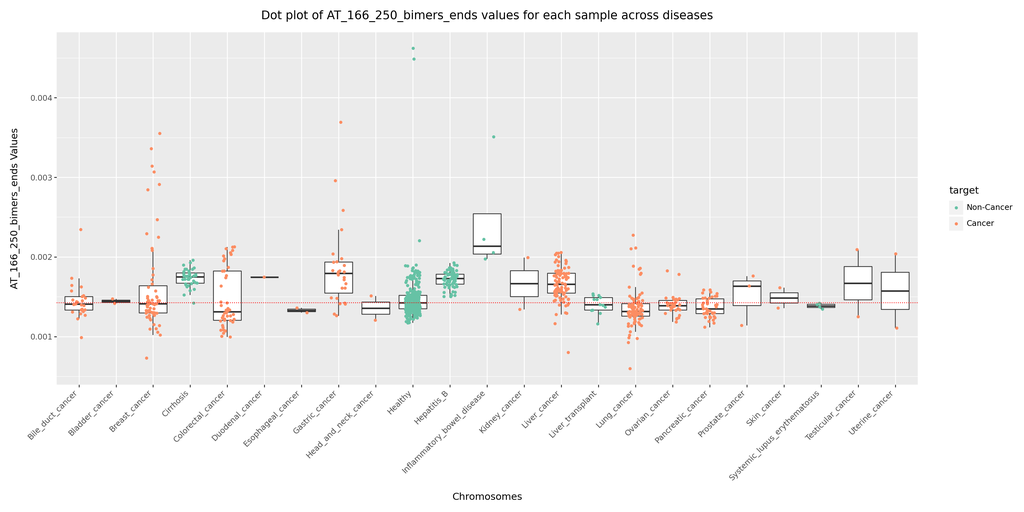

## **Feature Selection Process**

### **Result:**

- **Selected Features:** **78 Features** out of **76,801 Features** (0.1% selected)

## **TPOT**

[figure not shown]

### **Classifier Performance on Training Data**

#### **Best Classifiers After Training**

| Classifier | HP_count | Accuracy | Sensitivity | Specificity | Weighted_Score |
| --- | --- | --- | --- | --- | --- |
| BernoulliNB | 475 | 0.581818 | 0.240984 | 0.928333 | 0.652825 |
| ExtraTreesClassifier | 55 | 0.788430 | 0.660656 | 0.918333 | 0.815049 |
| RandomForestClassifier | 228 | 0.814876 | 0.762295 | 0.868333 | 0.825830 |
| XGBClassifier | 459 | 0.806612 | 0.798361 | 0.815000 | 0.808331 |

#### **Selected Classifiers for Full Training**

| Classifier | Count |
| --- | --- |
| RandomForestClassifier | 151 |
| XGBClassifier | 8 |

#### **Key Insights:**

- **Best Performers:** `RandomForestClassifier` and `XGBClassifier`
- **Next Step:** Evaluate the selected classifiers on the **blind test set** for performance validation.

### **Feature Importance for Training Data**

#### **Overlap of Top 10 Important Features by Classifier**

| Feature | RandomForestClassifier_228 | XGBClassifier_459 |
| --- | --- | --- |
| chr15-P60m-coverage | 1 | 1 |
| chr20-P5m-coverage | 2 | 6 |
| chr9-P125m-CT_bimers_starts | 3 | 4 |
| chr5-P65m-AG_bimers_ends | 4 | 2 |
| chr8-P40m-AG_bimers_ends | 5 | 8 |
| chr5-P100m-AG_bimers_ends | 7 | 5 |
| chr13-P95m-AG_166_250_bimers_starts | 8 | 9 |
| chr4-P180m-AG_bimers_ends | 10 | 3 |

#### **Key Insights:**

- **Top Feature for Both Models:** `chr15-P60m-coverage`
- **Different Feature Rankings:** Each classifier relies on slightly different features.
- **Outlook:** Analyze **biological significance** of top-ranked features.

#### **Visualizing Top 10 Important Features**

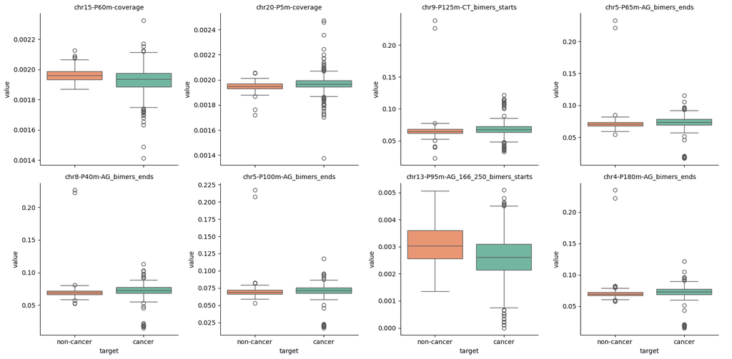

### **Classifier Performance on Blind Test Set**

#### **Results Overview:**

The following classifiers achieved perfect performance in predicting blind test set samples.

| Classifier | Accuracy | Sensitivity | Specificity | Confusion_Matrix |
| --- | --- | --- | --- | --- |
| RandomForestClassifier_228 | 1.000000 | 1.000000 | 1.000000 | [[81 0] [ 0 81]] |
| XGBClassifier_459 | 1.000000 | 1.000000 | 1.000000 | [[81 0] [ 0 81]] |

#### **Important Note:**

- **Testing on a larger sample size is needed** to obtain more **realistic accuracy values**.

## **Internship Takeaways**

### **What I Learned During My Internship**

#### **Technical & Analytical Skills:**

- **Python Development:** Advanced proficiency in Python coding and pandas for data analysis.
- **Linux Environment:** Comfortable working in Linux-based systems for data processing.
- **NGS Pipeline Development:** Experience in next-generation sequencing (NGS) workflow design and implementation.
- **Fragmentomics & Feature Engineering:** Expertise in fragmentomics, feature extraction, and feature selection.
- **Machine Learning & Model Development:** Applied ML techniques using TPOT and scikit-learn for predictive modeling.

## **Internship Takeaways**

### **What I Learned During My Internship**

#### **Business & Professional Insights:**

- **Start-Up Environment:** Gained insights into start-up dynamics, project management, and business development in a biotech setting.

**Takeaway:**  
This internship has significantly enhanced both my **technical** and **professional** skills, preparing me for future challenges in **computational biology**, **bioinformatics**, and **machine learning**.